# APIM for Distinguishable Dyads

Back to schedule

# Load the Data

Load packages and read in the pairwise dataset

```r
library(dyadr)
library(dplyr)
library(nlme)
library(ppcor)

riggsp <- read.csv("riggsp.csv")
```

# Distingushable Dyads

A run examining the effect of own Attachment Anxiety (Anxiety_A) and the effect of partner’s Attachment Anxiety (Anxiety_P) on satisfaction (Sat_A) separately for men and women (Gender_A or Genderstring), allowing for nonindependence by correlating the errors of the two members.

There are two approaches to running the distinguisable dyads APIM:

1. Interaction Approach
2. Two Intercept Approach

## Interaction Approach

Steps for using the interaction approach:

1. Add distinguishing variable as a covariate. Note it should be a integer, number, or double type variable. Check any variable’s type by running the `class()` function. For example, `class(riggsp$Gender_A)`. Here we have effects coded Gender_A (men = -1 and women = 1), but you could also dummy code, just be sure to note how you’ve done it.
2. Have the distinguishing variable interact with the actor and the partner effects. You can do this using the `*` symbol, or alternatively, the `:` symbol. Using `*` will force R to add the main effects, while `:` will only give you that specific interaction you’re asking for.
3. These interactions evaluate whether actor and partner effects are the same for the two people.
4. Add a `weights =` option the the `gls()` function to allow for different error variances for the two members. We are using the factor variable, `Genderstring`, here to make the output easier to read.

```r
apim_di_int <- gls(Sat_A ~ Anxiety_A + Anxiety_P + Gender_A
                      + Anxiety_A*Gender_A + Anxiety_P*Gender_A,
                   data = riggsp,
                   correlation = corCompSymm(form=~1|Dyad),
                   weights = varIdent(form=~1|Genderstring),
                   na.action = na.omit)

#This model is equivalent to the one above.
apim_di_int <- gls(Sat_A ~ Anxiety_A*Gender_A
                      + Anxiety_P*Gender_A,
                   data = riggsp,
                   correlation = corCompSymm(form=~1|Dyad),
                   weights = varIdent(form=~1|Genderstring),
                   na.action = na.omit)

smallsummary(apim_di_int)
```

```
## Correlation structure of class corCompSymm representing
##       Rho
## 0.6157989
##
## Variance function structure of class varIdent representing
##      Man    Woman
## 1.000000 1.028966
## Residual standard error: 6.638667
##
##                      Value Std.Error t-value p-value
## (Intercept)        53.3577    1.5079 35.3850  0.0000
## Anxiety_A          -1.7994    0.2974 -6.0504  0.0000
## Gender_A            0.4939    0.7356  0.6714  0.5025
## Anxiety_P          -1.2696    0.2969 -4.2754  0.0000
## Anxiety_A:Gender_A -0.1189    0.3356 -0.3544  0.7233
## Gender_A:Anxiety_P -0.0457    0.3352 -0.1365  0.8915
```

```
##                      2.5 %  97.5 %
## (Intercept)        50.4022 56.3132
## Anxiety_A          -2.3823 -1.2165
## Gender_A           -0.9479  1.9356
## Anxiety_P          -1.8516 -0.6876
## Anxiety_A:Gender_A -0.7767  0.5388
## Gender_A:Anxiety_P -0.7027  0.6112
```

### Interpretation of Effects

**Intercept** = 53.36—The predicted score for men and women who have a 0 on Anxious Attachment and their partners also have 0 for Anxious Attachment. (We should have centered!)

**Gender_A** = .49—Women are slightly more satisfied (about 1 point more) than men when you control for both members’ anxious attachment levels. (Recall women are 1 on Gender_A and men are -1; the difference between men and women is then 2x the effect of Gender_A.)

**Axiety_A** = -1.80—Actor Effect: The more anxiously attached you are, the less satisfied you are (controling for partner’s anxious attachment).

**Anxiety_P** = -1.27—Partner Effect: The more anxiously attached your partner is, the less satisfied you are (controling for your own anxious attachment).

**Anxiety_A:Gender_A** = -0.12—The actor effect is more strongly negative for women than for men (although not significantly so).

**Gender_A:Anxiety_P** = -0.05—The partner effect is more strongly negative for men->women than for women->men (although not significantly so).

When interpreting it may be helpful to compute the separate actor and partner effects for men and women.

**Actor Effect for Women** = -1.80 + (-0.12) = -1.92  
**Actor Effect for Men** = -1.80 - (-0.12) = -1.68  
**Partner Effect for M -> W** = -1.27 + (-0.05) = -1.32  
**Partner Effect for W -> M** = -1.27 - (-0.05) = -1.22

Or have R do it like so:

```r
sep_coef <- data.frame(
  anx_a_men = coef(apim_di_int)[2] + -1*coef(apim_di_int)[5],
  anx_a_wom = coef(apim_di_int)[2] + 1*coef(apim_di_int)[5],
  anx_p_men = coef(apim_di_int)[4] + -1*coef(apim_di_int)[6],
  anx_p_wom = coef(apim_di_int)[4] + 1*coef(apim_di_int)[6],
  row.names = "Randi's nums")

sep_coef
```

```
##              anx_a_men anx_a_wom anx_p_men anx_p_wom
## Randi's nums -1.680476  -1.91837 -1.223819 -1.315314
```

### Getting Separate Error Variances

Notice is the model summary that we now get weights for the error variances. That is, we actually have two separate error variances. We can use the function `getevd` in the `dyadr` package to retrieve them.

```r
error_vars <- data.frame(ev_wom = getevd(apim_di_int)[1],
                         ev_men = getevd(apim_di_int)[2])

error_vars
```

```
##           ev_wom   ev_men
## Group 1 6.830963 6.638667
```

6.83 is the error variance for women, and 6.64 is the error variance for men.

## Two-Intercept Approach

This involves a trick by which one equation becomes two. We create two dummy variables: $M_{ij}$ which equals 1 for men and 0 for women and $W_{ij}$ which equals 1 for women and zero for men. We then estimate the following equation:

$$Y_{ij} = b_MM_{ij} + a_MM_{ij}A_{ij} + p_MM_{ij}P_{ij} + M_{ij}e_{ij} + b_WW_{ij} + a_WW_{ij}A_{ij} + p_WW_{ij}P_{ij} + W_{ij}e_{ij}$$

Note that the equation has no ordinary intercept, but rather, in some sense, two intercepts, $b_M$ and $b_W$. Note that when $M_{ij} = 1$ and $W_{ij} = 0$, the above becomes

$$Y_{ij} = b_M + a_MA_{ij} + p_MP_{ij} + e_{ij}$$

and when $M_{ij} = 0$ and $W_{ij} = 1$, the above becomes

$$Y_{ij} = b_W + a_WA_{ij} + p_WP_{ij} + e_{ij}$$

Thus, one equation becomes two and we have actor and partner for both members.

To implement this in R, we do the following:

1. Add a distinguishing variable that is a factor type variable. We’ll use `Genderstring` to make the output nice.
2. Have no intercept in the fixed model by adding `-1` to the end of the formula.
3. Have the distinguishing variable (`Genderstring`) interact with actor and partner effect, but no actor and partner main effects. We need to use `:` for this instead of `*`. Separate actor and partner effects will be estimated for each member type.
4. Keep the `weights =` argument to allow for different error variances for the two members.

```r
apim_di_two <- gls(Sat_A ~ Genderstring + Anxiety_A:Genderstring
                   + Anxiety_P:Genderstring -1,
                   data = riggsp,
                   correlation = corCompSymm(form=~1|Dyad),
                   weights = varIdent(form=~1|Genderstring),
                   na.action = na.omit)

smallsummary(apim_di_two)
```

```
## Correlation structure of class corCompSymm representing
##       Rho
## 0.6157989
##
## Variance function structure of class varIdent representing
##      Man    Woman
## 1.000000 1.028966
## Residual standard error: 6.638667
##
##                               Value Std.Error t-value p-value
## GenderstringMan             52.8639    1.6536 31.9680  0.0000
## GenderstringWoman           53.8516    1.7015 31.6486  0.0000
## GenderstringMan:Anxiety_A   -1.6805    0.4310 -3.8989  0.0001
## GenderstringWoman:Anxiety_A -1.9184    0.4652 -4.1241  0.0000
## GenderstringMan:Anxiety_P   -1.2238    0.4521 -2.7072  0.0072
## GenderstringWoman:Anxiety_P -1.3153    0.4435 -2.9658  0.0033
```

```
##                               2.5 %  97.5 %
## GenderstringMan             49.6228 56.1049
## GenderstringWoman           50.5166 57.1865
## GenderstringMan:Anxiety_A   -2.5252 -0.8357
## GenderstringWoman:Anxiety_A -2.8301 -1.0067
## GenderstringMan:Anxiety_P   -2.1099 -0.3378
## GenderstringWoman:Anxiety_P -2.1845 -0.4461
```

Notice that these actor and partner estimates are the same as what we calculated above. But now we have p-values for them. So that’s cool.

```r
rbind(sep_coef,
      model = coef(summary(apim_di_two))[3:6,1],
      p_values = coef(summary(apim_di_two))[3:6,4])
```

```
##                 anx_a_men     anx_a_wom    anx_p_men    anx_p_wom
## Randi's nums -1.680475614 -1.918370e+00 -1.223819012 -1.315314348
## model        -1.680475614 -1.918370e+00 -1.223819012 -1.315314348
## p_values      0.000118932  4.807799e-05  0.007169707  0.003258215
```

# Effect sizes

Actor effect size for Men

```r
riggsp %>%
  filter(Genderstring == "Man") %$%
  pcor.test(Anxiety_A, Sat_A, Anxiety_P)[1] %>%
  as.numeric()
```

```
## [1] -0.3015266
```

Actor effect size for women

```r
riggsp %>%
  filter(Genderstring == "Woman") %$%
  pcor.test(Anxiety_A, Sat_A, Anxiety_P)[1] %>%
  as.numeric()
```

```
## [1] -0.3172312
```

Partner effect size for Men

```r
riggsp %>%
  filter(Genderstring == "Man") %$%
  pcor.test(Anxiety_P, Sat_A, Anxiety_A)[1] %>%
  as.numeric()
```

```
## [1] -0.214471
```

Partner effect size for women

```r
riggsp %>%
  filter(Genderstring == "Woman") %$%
  pcor.test(Anxiety_P, Sat_A, Anxiety_A)[1] %>%
  as.numeric()
```

```
## [1] -0.2338862
```

# R<sup>2</sup> for Men and Women

We could also get R<sup>2</sup> for men and women separately.

```r
apim_di_empty <- gls(Sat_A ~ Gender_A,
                   data = riggsp,
                   correlation = corCompSymm(form=~1|Dyad),
                   weights = varIdent(form=~1|Genderstring),
                   na.action = na.omit)

R_sqs <- data.frame(R_sq_wom = crsp(getevd(apim_di_two)[1],
                                    getevd(apim_di_empty)[1]),
                    R_sq_men = crsp(getevd(apim_di_two)[2],
                                    getevd(apim_di_empty)[2]))

R_sqs
```

```
##          R_sq_wom  R_sq_men
## Group 1 0.1621929 0.1431408
```

R<sup>2</sup> for women is 0.16, or 16% of the variance in satisfaction for women is explained by the model.  
R<sup>2</sup> for men is 0.14, or 14% of the variance in satisfaction for men is explained by the model.

# Descriptive Statistics by Gender

There are MANY ways to do this. I use the `dyplr` package.

```r
riggsp %>%
  select(Genderstring, Anxiety_A, Sat_A) %>%
  na.omit() %>% #omits only if missing on the variables included in select()
  group_by(Genderstring) %>%
  summarise(Anxiety_A_mean = mean(Anxiety_A),
            Anxiety_A_sd = sd(Anxiety_A),
            Sat_A_mean = mean(Sat_A),
            Sat_A_sd = sd(Sat_A),
            n = n())
```

```
## # A tibble: 2 x 6
##   Genderstring Anxiety_A_mean Anxiety_A_sd Sat_A_mean Sat_A_sd     n
##   <fct>                 <dbl>        <dbl>      <dbl>    <dbl> <int>
## 1 Man                    2.63         1.27       44.9     7.17   155
## 2 Woman                  2.93         1.21       44.8     7.46   155
```

# Model Diagnostics

We should also check that our assumptions are not violated.

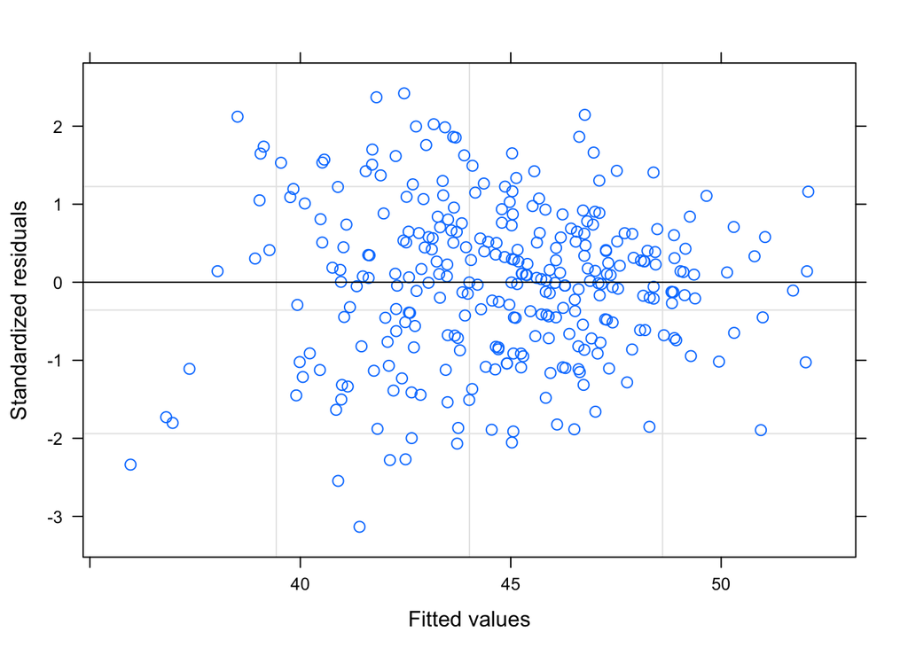

```r
plot(apim_di_int)
```

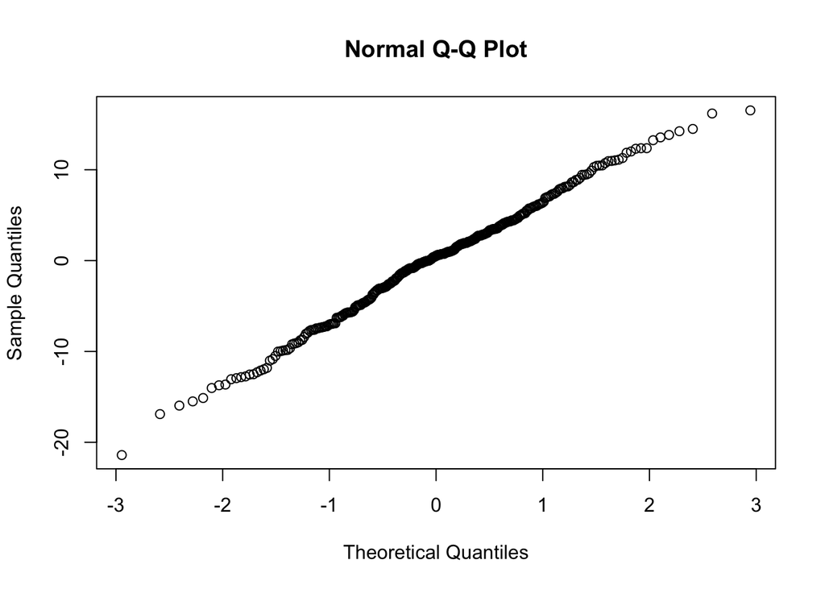

```r
qqnorm(apim_di_int$residuals)
```

Looks pretty good to me!

Back to schedule